# IBM_Final

```python
import matplotlib.pyplot as plt
import seaborn as sns
import numpy as np
import pandas as pd
```

```python
# print all the outputs in a cell
from IPython.core.interactiveshell import InteractiveShell
InteractiveShell.ast_node_interactivity = "all"
```

```python
pd.set_option('display.max_columns',100)
```

```python
df = pd.read_csv('HR.csv')
df.head()
```

|  | Age | Attrition | BusinessTravel | DailyRate | Department | DistanceFromHome | Education | EducationField | EmployeeCount | EmployeeNumber | EnvironmentSatisfaction | Gender | HourlyRate | JobInvolvement | JobLevel | JobRole | JobSatisfaction | MaritalStatus | MonthlyIncome | MonthlyRate | NumCompaniesWorked | Over18 | OverTime | PercentSalaryHike | PerformanceRating | RelationshipSatisfaction | StandardHours | StockOptionLevel | TotalWorkingYears | … |
| --- | --- | --- | --- | --- | --- | --- | --- | --- | --- | --- | --- | --- | --- | --- | --- | --- | --- | --- | --- | --- | --- | --- | --- | --- | --- | --- | --- | --- | --- | --- |
| 0 | 41 | Yes | Travel_Rarely | 1102 | Sales | 1 | 2 | Life Sciences | 1 | 1 | 2 | Female | 94 | 3 | 2 | Sales Executive | 4 | Single | 5993 | 19479 | 8 | Y | Yes | 11 | 3 | 1 | 80 | 0 | 8 | … |
| 1 | 49 | No | Travel_Frequently | 279 | Research & Development | 8 | 1 | Life Sciences | 1 | 2 | 3 | Male | 61 | 2 | 2 | Research Scientist | 2 | Married | 5130 | 24907 | 1 | Y | No | 23 | 4 | 4 | 80 | 1 | 10 | … |
| 2 | 37 | Yes | Travel_Rarely | 1373 | Research & Development | 2 | 2 | Other | 1 | 4 | 4 | Male | 92 | 2 | 1 | Laboratory Technician | 3 | Single | 2090 | 2396 | 6 | Y | Yes | 15 | 3 | 2 | 80 | 0 | 7 | … |
| 3 | 33 | No | Travel_Frequently | 1392 | Research & Development | 3 | 4 | Life Sciences | 1 | 5 | 4 | Female | 56 | 3 | 1 | Research Scientist | 3 | Married | 2909 | 23159 | 1 | Y | Yes | 11 | 3 | 3 | 80 | 0 | 8 | … |
| 4 | 27 | No | Travel_Rarely | 591 | Research & Development | 2 | 1 | Medical | 1 | 7 | 1 | Male | 40 | 3 | 1 | Laboratory Technician | 2 | Married | 3468 | 16632 | 9 | Y | No | 12 | 3 | 4 | 80 | 1 | 6 | … |

```python
df.shape
```

```
(1470, 35)
```

```python
df.info()
```

```
<class 'pandas.core.frame.DataFrame'>
RangeIndex: 1470 entries, 0 to 1469
Data columns (total 35 columns):
Age                         1470 non-null int64
Attrition                   1470 non-null object
BusinessTravel              1470 non-null object
DailyRate                   1470 non-null int64
Department                  1470 non-null object
DistanceFromHome            1470 non-null int64
Education                   1470 non-null int64
EducationField              1470 non-null object
EmployeeCount               1470 non-null int64
EmployeeNumber              1470 non-null int64
EnvironmentSatisfaction     1470 non-null int64
Gender                      1470 non-null object
HourlyRate                  1470 non-null int64
JobInvolvement              1470 non-null int64
JobLevel                    1470 non-null int64
JobRole                     1470 non-null object
JobSatisfaction             1470 non-null int64
MaritalStatus               1470 non-null object
MonthlyIncome               1470 non-null int64
MonthlyRate                 1470 non-null int64
NumCompaniesWorked          1470 non-null int64
Over18                      1470 non-null object
OverTime                    1470 non-null object
PercentSalaryHike           1470 non-null int64
PerformanceRating           1470 non-null int64
RelationshipSatisfaction    1470 non-null int64
StandardHours               1470 non-null int64
StockOptionLevel            1470 non-null int64
TotalWorkingYears           1470 non-null int64
TrainingTimesLastYear       1470 non-null int64
WorkLifeBalance             1470 non-null int64
YearsAtCompany              1470 non-null int64
YearsInCurrentRole          1470 non-null int64
YearsSinceLastPromotion     1470 non-null int64
YearsWithCurrManager        1470 non-null int64
dtypes: int64(26), object(9)
memory usage: 402.0+ KB
```

## Explore the missing value

```python
df.isnull().sum().head(20)
```

```
Age                        0
Attrition                  0
BusinessTravel             0
DailyRate                  0
Department                 0
DistanceFromHome           0
Education                  0
EducationField             0
EmployeeCount              0
EmployeeNumber             0
EnvironmentSatisfaction    0
Gender                     0
HourlyRate                 0
JobInvolvement             0
JobLevel                   0
JobRole                    0
JobSatisfaction            0
MaritalStatus              0
MonthlyIncome              0
MonthlyRate                0
dtype: int64
```

```python
df.isnull().sum().sum()
```

```
0
```

## Data Cleaning

- first replace Yes and No in Attrition with 1 and 0.

```python
df1 = df.copy()
```

```python
df1.replace(to_replace='Yes', value=1.0, inplace=True)
df1.replace(to_replace='Y', value=1.0, inplace=True)
df1.replace(to_replace='No', value= 0.0 , inplace=True)
df1.replace(to_replace='N', value= 0.0, inplace=True)
```

```python
df1.head()
```

|  | Age | Attrition | BusinessTravel | DailyRate | Department | DistanceFromHome | Education | EducationField | EmployeeCount | EmployeeNumber | EnvironmentSatisfaction | Gender | HourlyRate | JobInvolvement | JobLevel | JobRole | JobSatisfaction | MaritalStatus | MonthlyIncome | MonthlyRate | NumCompaniesWorked | Over18 | OverTime | PercentSalaryHike | PerformanceRating | RelationshipSatisfaction | StandardHours | StockOptionLevel | TotalWorkingYears | … |
| --- | --- | --- | --- | --- | --- | --- | --- | --- | --- | --- | --- | --- | --- | --- | --- | --- | --- | --- | --- | --- | --- | --- | --- | --- | --- | --- | --- | --- | --- | --- |
| 0 | 41 | 1.0 | Travel_Rarely | 1102 | Sales | 1 | 2 | Life Sciences | 1 | 1 | 2 | Female | 94 | 3 | 2 | Sales Executive | 4 | Single | 5993 | 19479 | 8 | 1.0 | 1.0 | 11 | 3 | 1 | 80 | 0 | 8 | … |
| 1 | 49 | 0.0 | Travel_Frequently | 279 | Research & Development | 8 | 1 | Life Sciences | 1 | 2 | 3 | Male | 61 | 2 | 2 | Research Scientist | 2 | Married | 5130 | 24907 | 1 | 1.0 | 0.0 | 23 | 4 | 4 | 80 | 1 | 10 | … |
| 2 | 37 | 1.0 | Travel_Rarely | 1373 | Research & Development | 2 | 2 | Other | 1 | 4 | 4 | Male | 92 | 2 | 1 | Laboratory Technician | 3 | Single | 2090 | 2396 | 6 | 1.0 | 1.0 | 15 | 3 | 2 | 80 | 0 | 7 | … |
| 3 | 33 | 0.0 | Travel_Frequently | 1392 | Research & Development | 3 | 4 | Life Sciences | 1 | 5 | 4 | Female | 56 | 3 | 1 | Research Scientist | 3 | Married | 2909 | 23159 | 1 | 1.0 | 1.0 | 11 | 3 | 3 | 80 | 0 | 8 | … |
| 4 | 27 | 0.0 | Travel_Rarely | 591 | Research & Development | 2 | 1 | Medical | 1 | 7 | 1 | Male | 40 | 3 | 1 | Laboratory Technician | 2 | Married | 3468 | 16632 | 9 | 1.0 | 0.0 | 12 | 3 | 4 | 80 | 1 | 6 | … |

- For Gender column, transfer Female into 0, Male into 1

```python
df1.replace(to_replace='Male', value= 1.0, inplace=True)
df1.replace(to_replace='Female', value= 0.0, inplace=True)
```

```python
df1.head()
```

|  | Age | Attrition | BusinessTravel | DailyRate | Department | DistanceFromHome | Education | EducationField | EmployeeCount | EmployeeNumber | EnvironmentSatisfaction | Gender | HourlyRate | JobInvolvement | JobLevel | JobRole | JobSatisfaction | MaritalStatus | MonthlyIncome | MonthlyRate | NumCompaniesWorked | Over18 | OverTime | PercentSalaryHike | PerformanceRating | RelationshipSatisfaction | StandardHours | StockOptionLevel | TotalWorkingYears | … |
| --- | --- | --- | --- | --- | --- | --- | --- | --- | --- | --- | --- | --- | --- | --- | --- | --- | --- | --- | --- | --- | --- | --- | --- | --- | --- | --- | --- | --- | --- | --- |
| 0 | 41 | 1.0 | Travel_Rarely | 1102 | Sales | 1 | 2 | Life Sciences | 1 | 1 | 2 | 0.0 | 94 | 3 | 2 | Sales Executive | 4 | Single | 5993 | 19479 | 8 | 1.0 | 1.0 | 11 | 3 | 1 | 80 | 0 | 8 | … |
| 1 | 49 | 0.0 | Travel_Frequently | 279 | Research & Development | 8 | 1 | Life Sciences | 1 | 2 | 3 | 1.0 | 61 | 2 | 2 | Research Scientist | 2 | Married | 5130 | 24907 | 1 | 1.0 | 0.0 | 23 | 4 | 4 | 80 | 1 | 10 | … |
| 2 | 37 | 1.0 | Travel_Rarely | 1373 | Research & Development | 2 | 2 | Other | 1 | 4 | 4 | 1.0 | 92 | 2 | 1 | Laboratory Technician | 3 | Single | 2090 | 2396 | 6 | 1.0 | 1.0 | 15 | 3 | 2 | 80 | 0 | 7 | … |
| 3 | 33 | 0.0 | Travel_Frequently | 1392 | Research & Development | 3 | 4 | Life Sciences | 1 | 5 | 4 | 0.0 | 56 | 3 | 1 | Research Scientist | 3 | Married | 2909 | 23159 | 1 | 1.0 | 1.0 | 11 | 3 | 3 | 80 | 0 | 8 | … |
| 4 | 27 | 0.0 | Travel_Rarely | 591 | Research & Development | 2 | 1 | Medical | 1 | 7 | 1 | 1.0 | 40 | 3 | 1 | Laboratory Technician | 2 | Married | 3468 | 16632 | 9 | 1.0 | 0.0 | 12 | 3 | 4 | 80 | 1 | 6 | … |

```python
df1.info()
```

```
<class 'pandas.core.frame.DataFrame'>
RangeIndex: 1470 entries, 0 to 1469
Data columns (total 35 columns):
Age                         1470 non-null int64
Attrition                   1470 non-null float64
BusinessTravel              1470 non-null object
DailyRate                   1470 non-null int64
Department                  1470 non-null object
DistanceFromHome            1470 non-null int64
Education                   1470 non-null int64
EducationField              1470 non-null object
EmployeeCount               1470 non-null int64
EmployeeNumber              1470 non-null int64
EnvironmentSatisfaction     1470 non-null int64
Gender                      1470 non-null float64
HourlyRate                  1470 non-null int64
JobInvolvement              1470 non-null int64
JobLevel                    1470 non-null int64
JobRole                     1470 non-null object
JobSatisfaction             1470 non-null int64
MaritalStatus               1470 non-null object
MonthlyIncome               1470 non-null int64
MonthlyRate                 1470 non-null int64
NumCompaniesWorked          1470 non-null int64
Over18                      1470 non-null float64
OverTime                    1470 non-null float64
PercentSalaryHike           1470 non-null int64
PerformanceRating           1470 non-null int64
RelationshipSatisfaction    1470 non-null int64
StandardHours               1470 non-null int64
StockOptionLevel            1470 non-null int64
TotalWorkingYears           1470 non-null int64
TrainingTimesLastYear       1470 non-null int64
WorkLifeBalance             1470 non-null int64
YearsAtCompany              1470 non-null int64
YearsInCurrentRole          1470 non-null int64
YearsSinceLastPromotion     1470 non-null int64
YearsWithCurrManager        1470 non-null int64
dtypes: float64(4), int64(26), object(5)
memory usage: 402.0+ KB
```

```python
df = df1
```

## Exploratory data analysis

```python
df.groupby(by=['Attrition'])[['Age']].mean()
```

| Attrition | Age |
| --- | --- |
| 0.0 | 37.561233 |
| 1.0 | 33.607595 |

```python
df1 = df.copy()
```

```python
df1['Age_bin'] = pd.cut(df1.Age,5)
```

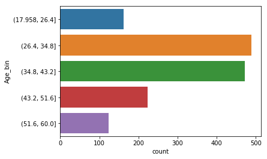

```python
sns.countplot(y='Age_bin', data=df1)
```

```python
df1.groupby(by=['Department'])['Department'].size()
```

```
Department
Human Resources            63
Research & Development    961
Sales                     446
Name: Department, dtype: int64
```

```python
df1['satisfaction'] = df1.RelationshipSatisfaction + df1.EnvironmentSatisfaction + df1.JobSatisfaction
```

```python
df1.groupby(by=['Department'])[['OverTime','WorkLifeBalance','satisfaction','MonthlyIncome',\
                                'PercentSalaryHike','StockOptionLevel','Attrition']].mean()
```

| Department | OverTime | WorkLifeBalance | satisfaction | MonthlyIncome | PercentSalaryHike | StockOptionLevel | Attrition |
| --- | --- | --- | --- | --- | --- | --- | --- |
| Human Resources | 0.269841 | 2.920635 | 8.174603 | 6654.507937 | 14.761905 | 0.777778 | 0.190476 |
| Research & Development | 0.281998 | 2.725286 | 8.178980 | 6281.252862 | 15.291363 | 0.804370 | 0.138398 |
| Sales | 0.286996 | 2.816143 | 8.125561 | 6959.172646 | 15.096413 | 0.773543 | 0.206278 |

```python
df1['bin_satis'] = pd.cut(df1.satisfaction,3)
```

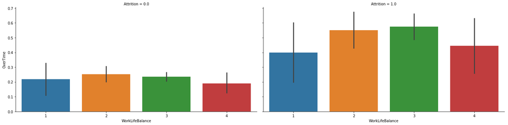

```python
sns.catplot(x='WorkLifeBalance', y='OverTime',col = 'Attrition', data=df1, kind ='bar',aspect = 2)
```

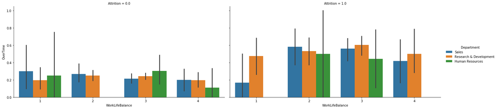

```python
sns.catplot(x='WorkLifeBalance', y='OverTime',col = 'Attrition', hue='Department', data=df1, kind ='bar',aspect = 2)
```

```python
# Most of them may still work at home after going off work
df1[(df1.Attrition == 1) & (df1.WorkLifeBalance ==1)].groupby('Department')['Department'].size()
```

```
Department
Research & Development    19
Sales                      6
Name: Department, dtype: int64
```

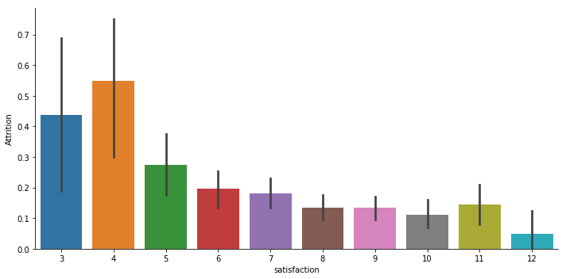

```python
sns.catplot(x='satisfaction', y = 'Attrition', data=df1, kind ='bar',aspect = 2)
```

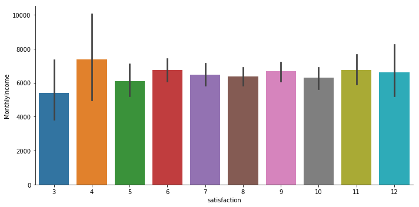

```python
sns.catplot(x='satisfaction', y = 'MonthlyIncome', data=df1, kind ='bar',aspect = 2)
```

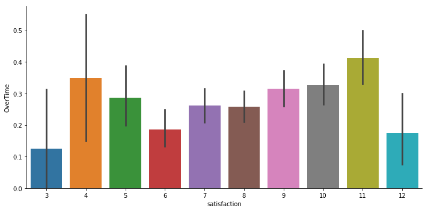

```python
# U-shape -> another interesting point
sns.catplot(x='satisfaction', y = 'OverTime', data=df1, kind ='bar',aspect = 2)
```

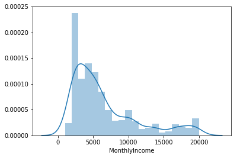

```python
# explore the distribution of monthly income among all employees
sns.distplot(df1.MonthlyIncome)
```

### One-hot encoding

- 'BusinessTravel','Department','EducationField','JobRole','MaritalStatus' are categorical data, we need to transfer them into numercial data which can be recognized by the ML model.

```python
df1 = df.copy()
```

```python
list1 = ['BusinessTravel','Department','EducationField','JobRole','MaritalStatus']

def one_hot(df,L):
    for i in L:
        df = pd.get_dummies(df,columns = [i])
    return df
```

```python
df1 = one_hot(df1,list1)
```

```python
df1.head()
```

|  | Age | Attrition | DailyRate | DistanceFromHome | Education | EmployeeCount | EmployeeNumber | EnvironmentSatisfaction | Gender | HourlyRate | JobInvolvement | JobLevel | JobSatisfaction | MonthlyIncome | MonthlyRate | NumCompaniesWorked | Over18 | OverTime | PercentSalaryHike | PerformanceRating | RelationshipSatisfaction | StandardHours | StockOptionLevel | TotalWorkingYears | TrainingTimesLastYear | WorkLifeBalance | YearsAtCompany | YearsInCurrentRole | YearsSinceLastPromotion | … |
| --- | --- | --- | --- | --- | --- | --- | --- | --- | --- | --- | --- | --- | --- | --- | --- | --- | --- | --- | --- | --- | --- | --- | --- | --- | --- | --- | --- | --- | --- | --- |
| 0 | 41 | 1.0 | 1102 | 1 | 2 | 1 | 1 | 2 | 0.0 | 94 | 3 | 2 | 4 | 5993 | 19479 | 8 | 1.0 | 1.0 | 11 | 3 | 1 | 80 | 0 | 8 | 0 | 1 | 6 | 4 | 0 | … |
| 1 | 49 | 0.0 | 279 | 8 | 1 | 1 | 2 | 3 | 1.0 | 61 | 2 | 2 | 2 | 5130 | 24907 | 1 | 1.0 | 0.0 | 23 | 4 | 4 | 80 | 1 | 10 | 3 | 3 | 10 | 7 | 1 | … |
| 2 | 37 | 1.0 | 1373 | 2 | 2 | 1 | 4 | 4 | 1.0 | 92 | 2 | 1 | 3 | 2090 | 2396 | 6 | 1.0 | 1.0 | 15 | 3 | 2 | 80 | 0 | 7 | 3 | 3 | 0 | 0 | 0 | … |
| 3 | 33 | 0.0 | 1392 | 3 | 4 | 1 | 5 | 4 | 0.0 | 56 | 3 | 1 | 3 | 2909 | 23159 | 1 | 1.0 | 1.0 | 11 | 3 | 3 | 80 | 0 | 8 | 3 | 3 | 8 | 7 | 3 | … |
| 4 | 27 | 0.0 | 591 | 2 | 1 | 1 | 7 | 1 | 1.0 | 40 | 3 | 1 | 2 | 3468 | 16632 | 9 | 1.0 | 0.0 | 12 | 3 | 4 | 80 | 1 | 6 | 3 | 3 | 2 | 2 | 2 | … |

## Build a Decision Tree Model to explore feature importance

```python
import sklearn as sk
import sklearn.tree as tree
from IPython.display import Image
import pydotplus
```

```python
x = df1.drop(['Attrition'],axis=1)
```

```python
x.head()
```

|  | Age | DailyRate | DistanceFromHome | Education | EmployeeCount | EmployeeNumber | EnvironmentSatisfaction | Gender | HourlyRate | JobInvolvement | JobLevel | JobSatisfaction | MonthlyIncome | MonthlyRate | NumCompaniesWorked | Over18 | OverTime | PercentSalaryHike | PerformanceRating | RelationshipSatisfaction | StandardHours | StockOptionLevel | TotalWorkingYears | TrainingTimesLastYear | WorkLifeBalance | YearsAtCompany | YearsInCurrentRole | YearsSinceLastPromotion | YearsWithCurrManager | … |
| --- | --- | --- | --- | --- | --- | --- | --- | --- | --- | --- | --- | --- | --- | --- | --- | --- | --- | --- | --- | --- | --- | --- | --- | --- | --- | --- | --- | --- | --- | --- |
| 0 | 41 | 1102 | 1 | 2 | 1 | 1 | 2 | 0.0 | 94 | 3 | 2 | 4 | 5993 | 19479 | 8 | 1.0 | 1.0 | 11 | 3 | 1 | 80 | 0 | 8 | 0 | 1 | 6 | 4 | 0 | 5 | … |
| 1 | 49 | 279 | 8 | 1 | 1 | 2 | 3 | 1.0 | 61 | 2 | 2 | 2 | 5130 | 24907 | 1 | 1.0 | 0.0 | 23 | 4 | 4 | 80 | 1 | 10 | 3 | 3 | 10 | 7 | 1 | 7 | … |
| 2 | 37 | 1373 | 2 | 2 | 1 | 4 | 4 | 1.0 | 92 | 2 | 1 | 3 | 2090 | 2396 | 6 | 1.0 | 1.0 | 15 | 3 | 2 | 80 | 0 | 7 | 3 | 3 | 0 | 0 | 0 | 0 | … |
| 3 | 33 | 1392 | 3 | 4 | 1 | 5 | 4 | 0.0 | 56 | 3 | 1 | 3 | 2909 | 23159 | 1 | 1.0 | 1.0 | 11 | 3 | 3 | 80 | 0 | 8 | 3 | 3 | 8 | 7 | 3 | 0 | … |
| 4 | 27 | 591 | 2 | 1 | 1 | 7 | 1 | 1.0 | 40 | 3 | 1 | 2 | 3468 | 16632 | 9 | 1.0 | 0.0 | 12 | 3 | 4 | 80 | 1 | 6 | 3 | 3 | 2 | 2 | 2 | 2 | … |

```python
y = df1.Attrition
```

```python
dt = tree.DecisionTreeClassifier(max_depth=2)
```

```python
import warnings
#suppress all future warning
warnings.filterwarnings('ignore')
#see only one time warning
#warnings.filterwarnings(action='once')
```

```python
dt.fit(x,y)
```

```
DecisionTreeClassifier(class_weight=None, criterion='gini', max_depth=2,
            max_features=None, max_leaf_nodes=None,
            min_impurity_decrease=0.0, min_impurity_split=None,
            min_samples_leaf=1, min_samples_split=2,
            min_weight_fraction_leaf=0.0, presort=False, random_state=None,
            splitter='best')
```

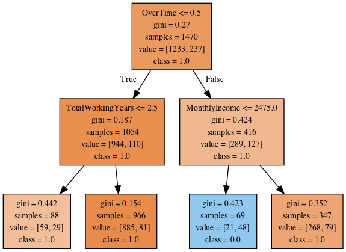

```python
dt_feature_names = list(x.columns)
dt_target_names = [str(s) for s in y.unique()]
tree.export_graphviz(dt, out_file='tree.dot',
    feature_names=dt_feature_names, class_names=dt_target_names,
    filled=True)
graph = pydotplus.graph_from_dot_file('tree.dot')
Image(graph.create_png())
```

```python
dt.feature_importances_
```

```
array([0.        , 0.        , 0.        , 0.        , 0.        ,
       0.        , 0.        , 0.        , 0.        , 0.        ,
       0.        , 0.        , 0.42707352, 0.        , 0.        ,
       0.        , 0.4079732 , 0.        , 0.        , 0.        ,
       0.        , 0.        , 0.16495328, 0.        , 0.        ,
       0.        , 0.        , 0.        , 0.        , 0.        ,
       0.        , 0.        , 0.        , 0.        , 0.        ,
       0.        , 0.        , 0.        , 0.        , 0.        ,
       0.        , 0.        , 0.        , 0.        , 0.        ,
       0.        , 0.        , 0.        , 0.        , 0.        ,
       0.        , 0.        , 0.        ])
```

```python
d = {x.columns[i] : dt.feature_importances_[i] for i in range(0,len(x.columns))}
```

```python
s = pd.Series(d)
s.nlargest(3)
```

```
MonthlyIncome        0.427074
OverTime             0.407973
TotalWorkingYears    0.164953
dtype: float64
```

```python
import plotly.graph_objs as go
import plotly.offline as py
```

```python
trace = go.Scatter(
    y = dt.feature_importances_,
    x = x.columns.values,
    mode='markers',
    marker=dict(
        sizemode = 'diameter',
        sizeref = 1,
        size = 13,
        #size= rf.feature_importances_,
        #color = np.random.randn(500), #set color equal to a variable
        color = dt.feature_importances_,
        colorscale='Portland',
        showscale=True
    ),
    text = x.columns.values
)
data = [trace]

layout= go.Layout(
    autosize= True,
    title= 'Decision Tree Feature Importance',
    hovermode= 'closest',
     xaxis= dict(
         ticklen= 5,
         showgrid=False,
        zeroline=False,
        showline=False
     ),
     yaxis=dict(
        title= 'Feature Importance',
        showgrid=False,
        zeroline=False,
        ticklen= 5,
        gridwidth= 2
    ),
    showlegend= False
)
fig = go.Figure(data=data, layout=layout)
py.iplot(fig,filename='scatter2010')
```

[interactive chart not shown]

## Three Interesting Points

### Point 1: How to attract more young talents?

```python
# K-Means Model
from sklearn.cluster import KMeans
```

```python
clu = KMeans(n_clusters=3, random_state=0)
clu
```

```
KMeans(algorithm='auto', copy_x=True, init='k-means++', max_iter=300,
    n_clusters=3, n_init=10, n_jobs=1, precompute_distances='auto',
    random_state=0, tol=0.0001, verbose=0)
```

```python
# Normalization
from sklearn.preprocessing import StandardScaler
ss = StandardScaler()
df2nol =ss.fit_transform(df1)
```

```python
clu.fit(df2nol)
```

```
KMeans(algorithm='auto', copy_x=True, init='k-means++', max_iter=300,
    n_clusters=3, n_init=10, n_jobs=1, precompute_distances='auto',
    random_state=0, tol=0.0001, verbose=0)
```

```python
clu.labels_
```

```
array([2, 1, 1, ..., 1, 2, 1], dtype=int32)
```

```python
# Getting summary information on the clusters' characteristics
```

```python
df1['cluster']=clu.labels_
```

```python
# Cluster all the employees to 3 groups
df1.groupby('cluster').mean()
```

| cluster | Age | Attrition | DailyRate | DistanceFromHome | Education | EmployeeCount | EmployeeNumber | EnvironmentSatisfaction | Gender | HourlyRate | JobInvolvement | JobLevel | JobSatisfaction | MonthlyIncome | MonthlyRate | NumCompaniesWorked | Over18 | OverTime | PercentSalaryHike | PerformanceRating | RelationshipSatisfaction | StandardHours | StockOptionLevel | TotalWorkingYears | TrainingTimesLastYear | WorkLifeBalance | YearsAtCompany | YearsInCurrentRole | YearsSinceLastPromotion | … |
| --- | --- | --- | --- | --- | --- | --- | --- | --- | --- | --- | --- | --- | --- | --- | --- | --- | --- | --- | --- | --- | --- | --- | --- | --- | --- | --- | --- | --- | --- | --- |
| 0 | 46.075697 | 0.055777 | 808.872510 | 8.924303 | 3.083665 | 1.0 | 968.685259 | 2.713147 | 0.517928 | 66.055777 | 2.717131 | 3.924303 | 2.661355 | 15026.027888 | 14691.179283 | 3.338645 | 1.0 | 0.298805 | 15.095618 | 3.159363 | 2.796813 | 80.0 | 0.804781 | 23.581673 | 2.749004 | 2.756972 | 13.916335 | 7.007968 | 4.852590 | … |
| 1 | 34.975580 | 0.164835 | 802.045177 | 9.185592 | 2.859585 | 1.0 | 1027.958486 | 2.743590 | 0.628816 | 66.192918 | 2.750916 | 1.506716 | 2.726496 | 4174.199023 | 14082.162393 | 2.606838 | 1.0 | 0.274725 | 15.300366 | 3.162393 | 2.710623 | 80.0 | 0.799756 | 8.452991 | 2.775336 | 2.728938 | 5.299145 | 3.435897 | 1.472527 | … |
| 2 | 35.170000 | 0.220000 | 799.380000 | 9.375000 | 2.915000 | 1.0 | 1053.785000 | 2.682500 | 0.592500 | 65.170000 | 2.695000 | 2.037500 | 2.775000 | 5922.767500 | 14548.712500 | 2.465000 | 1.0 | 0.290000 | 15.095000 | 3.132500 | 2.662500 | 80.0 | 0.775000 | 9.347500 | 2.880000 | 2.830000 | 6.172500 | 4.110000 | 1.980000 | … |

- Group 0 - Senior Manager
- Group 1 - Young Talent (R&D)
- Group 2 - Young Talent (Sales)

```python
df_young = df1[df1.cluster != 0]
df_young.head()
```

|  | Age | Attrition | DailyRate | DistanceFromHome | Education | EmployeeCount | EmployeeNumber | EnvironmentSatisfaction | Gender | HourlyRate | JobInvolvement | JobLevel | JobSatisfaction | MonthlyIncome | MonthlyRate | NumCompaniesWorked | Over18 | OverTime | PercentSalaryHike | PerformanceRating | RelationshipSatisfaction | StandardHours | StockOptionLevel | TotalWorkingYears | TrainingTimesLastYear | WorkLifeBalance | YearsAtCompany | YearsInCurrentRole | YearsSinceLastPromotion | … |
| --- | --- | --- | --- | --- | --- | --- | --- | --- | --- | --- | --- | --- | --- | --- | --- | --- | --- | --- | --- | --- | --- | --- | --- | --- | --- | --- | --- | --- | --- | --- |
| 0 | 41 | 1.0 | 1102 | 1 | 2 | 1 | 1 | 2 | 0.0 | 94 | 3 | 2 | 4 | 5993 | 19479 | 8 | 1.0 | 1.0 | 11 | 3 | 1 | 80 | 0 | 8 | 0 | 1 | 6 | 4 | 0 | … |
| 1 | 49 | 0.0 | 279 | 8 | 1 | 1 | 2 | 3 | 1.0 | 61 | 2 | 2 | 2 | 5130 | 24907 | 1 | 1.0 | 0.0 | 23 | 4 | 4 | 80 | 1 | 10 | 3 | 3 | 10 | 7 | 1 | … |
| 2 | 37 | 1.0 | 1373 | 2 | 2 | 1 | 4 | 4 | 1.0 | 92 | 2 | 1 | 3 | 2090 | 2396 | 6 | 1.0 | 1.0 | 15 | 3 | 2 | 80 | 0 | 7 | 3 | 3 | 0 | 0 | 0 | … |
| 3 | 33 | 0.0 | 1392 | 3 | 4 | 1 | 5 | 4 | 0.0 | 56 | 3 | 1 | 3 | 2909 | 23159 | 1 | 1.0 | 1.0 | 11 | 3 | 3 | 80 | 0 | 8 | 3 | 3 | 8 | 7 | 3 | … |
| 4 | 27 | 0.0 | 591 | 2 | 1 | 1 | 7 | 1 | 1.0 | 40 | 3 | 1 | 2 | 3468 | 16632 | 9 | 1.0 | 0.0 | 12 | 3 | 4 | 80 | 1 | 6 | 3 | 3 | 2 | 2 | 2 | … |

```python
df_young['binned_income'] = pd.qcut(df_young.MonthlyIncome,5)
```

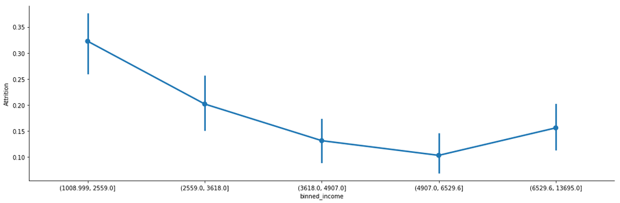

```python
# U shape
sns.catplot(x='binned_income',y='Attrition',data=df_young, kind='point',aspect = 3)
```

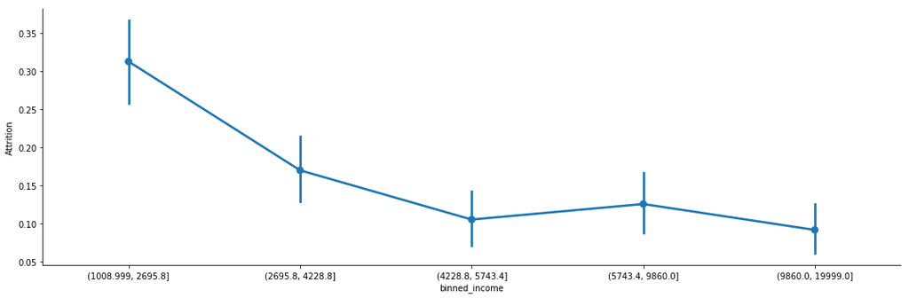

```python
# If we plot for everyone:
df1['binned_income'] = pd.qcut(df1.MonthlyIncome,5)
sns.catplot(x='binned_income',y='Attrition',data=df1, kind='point',aspect = 3)
```

### Point 2: Money is The Root of All Decisions...Right?

- Money is not the only reason why one would quit

```python
# Let's take a look at the total number of attrition based on departments
df.groupby('Department')[['Attrition']].sum()
```

| Department | Attrition |
| --- | --- |
| Human Resources | 12.0 |
| Research & Development | 133.0 |
| Sales | 92.0 |

- The attrition proportion takes into account only the employees who quit; R&D comprises of ~56% of attrition.
- We will focus on R&D because there is a large portion of R&D employees who quit.

```python
(df.groupby('Department').agg({'Attrition':'sum'})\
            .rename(columns={'Attrition':'Attrition_Proportion'}))\
            /len(df[df.Attrition == 1])
```

| Department | Attrition_Proportion |
| --- | --- |
| Human Resources | 0.050633 |
| Research & Development | 0.561181 |
| Sales | 0.388186 |

- First attribute We immediately thought of is 'RelationshipSatisfaction'. That's an employee's satisfaction with manager and/or colleagues. In R&D department for those who quit/not quit and rated as 4, they made roughly the same amount of monthly income.

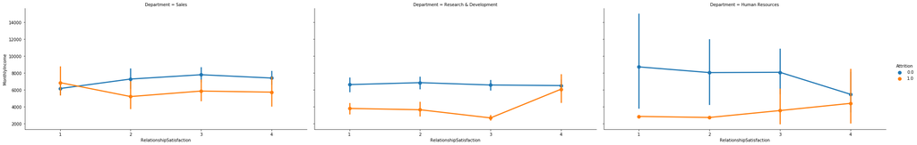

```python
sns.catplot(x='RelationshipSatisfaction',y='MonthlyIncome', hue='Attrition', \
            col='Department', kind='point', data=df, aspect=2)
```

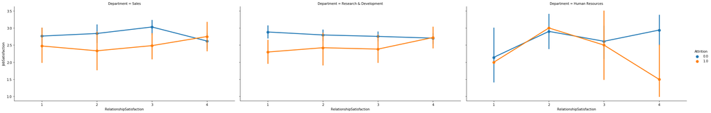

```python
sns.catplot(x='RelationshipSatisfaction',y='JobSatisfaction', hue='Attrition', \
            col='Department', kind='point', data=df, aspect=2)
```

- Point of this finding: Job satisfaction also plays a role. Money is not always the reason why some employees stay. Some employees want their jobs to be very satisfying. Start putting more emphasis into developing R&D Department.

**Suggestion for boss:**  
Scale the R&D Department:  
1) More strategic projects  
2) Increase budget  
- Create more higher-tier roles  
- Create more promotion opportunities  
- Create more workshops  
Important: Ensure changes do not compromise high relationship satisfaction

### Point 3: Why are Research Directors Quitting?

Based on the above intersting points, we decided to look deeper at one specific job role, so see if an interesting or unusual information can be found.

Because monthly income is the most important feature, we dicided to look for Job Roles where monthly income was higher for those who quit than those who didnt quit. We started with the hypothesis that it ia assumed that those who get paid more, would be less likely to quit, and we wanted to find evidence and data where that assumption didnt hold.

Employees Who Quit made, on average, ___% more in Monthly Income than those who didn't quit

- Healthcare Representative - 15% more
- Manufacturing Director - 1% more
- **Research Director - 22% more**
- Sales Executive - 10% more

```python
df.groupby(['JobRole','Attrition'])['MonthlyIncome'].mean()
```

```
JobRole                    Attrition
Healthcare Representative  0.0           7453.557377
                           1.0           8548.222222
Human Resources            0.0           4391.750000
                           1.0           3715.750000
Laboratory Technician      0.0           3337.223350
                           1.0           2919.258065
Manager                    0.0          17201.484536
                           1.0          16797.400000
Manufacturing Director     0.0           7289.925926
                           1.0           7365.500000
Research Director          0.0          15947.346154
                           1.0          19395.500000
Research Scientist         0.0           3328.122449
                           1.0           2780.468085
Sales Executive            0.0           6804.617100
                           1.0           7489.000000
Sales Representative       0.0           2798.440000
                           1.0           2364.727273
Name: MonthlyIncome, dtype: float64
```

```python
# Let us focus on Research Director only
df_RD = df[df.JobRole == 'Research Director']
```

- Possible reasons attrition is occuring

(1) Marital Status - Non-Actionable

We were hoping to see a difference between married and single employees who did/did not quit, but there was nothing that stood out. Incomes were equal between Married and single, both for people who quit and those that didnt.

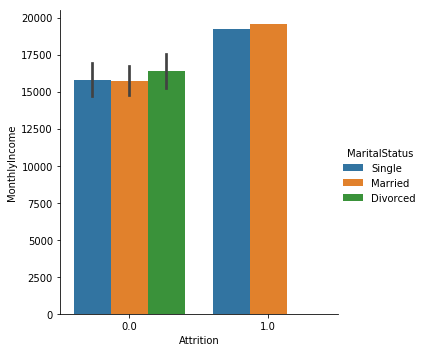

```python
sns.catplot(x='Attrition', y='MonthlyIncome', hue='MaritalStatus', data=df_RD, kind='bar')
```

(2) Distance From Home - Non-Actionable

We were hoping to see that cusotmers who lived farther away, and who get paid less, would quit. This data does not show that, but shows that those who did quit, made more than other who lived the same distance way, so there is something else causing them to quit.

```python
df_RD['binned_distancefromhome'] = pd.cut(df_RD.DistanceFromHome,5)
```

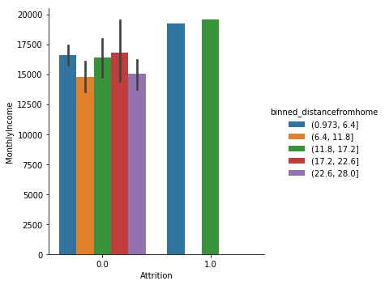

```python
sns.catplot(x='Attrition', y='MonthlyIncome', hue='binned_distancefromhome', data=df_RD, kind='bar')
```

(3) Business Travel - Semi-Actionable

Seems like Research Directors who did travel rarely quit, but were making more than their counterparts who also traveled rarely, so this could be one reason these emplyees are quitting. But since we dont see frequent travlers quitting, it doesnt seem like this is the main driver of Research Directors quitting.

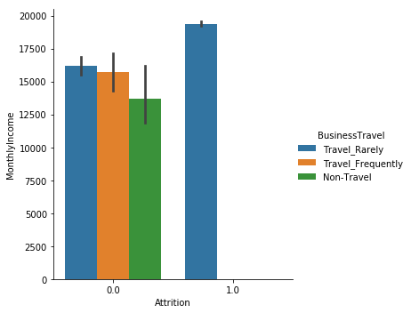

```python
sns.catplot(x='Attrition', y='MonthlyIncome', hue='BusinessTravel', data=df_RD, kind='bar')
```

(4) Job Satisfaction - Actionable

It appears that Research Directors who gave a below average Job Satisfaction rating (1 or 2), this could be there reason for qutting. If the employee hates there job, no amount of money can get the to stay. But, since there are also some employees who gave above average rating (3 or 4), who still quit, then there is still something else causing them to quit.

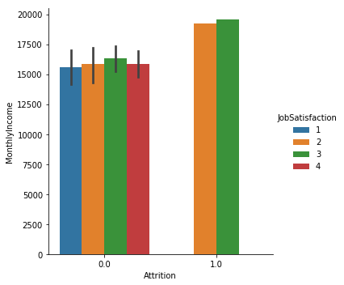

```python
sns.catplot(x='Attrition', y='MonthlyIncome', hue='JobSatisfaction', data=df_RD, kind='bar')
```

(5) Gender - Not Actionable

Was looking to see if therer was a substantial difference in pay between genders, which might explain why some are qutting, but the data shows that the females who quit were making more than their counterparts who didnt quit.

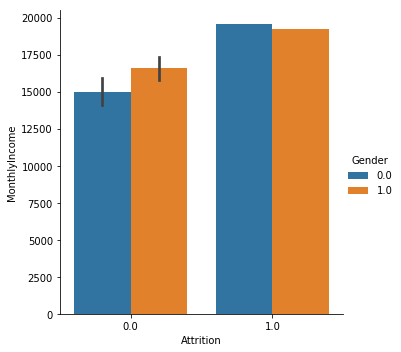

```python
sns.catplot(x='Attrition', y='MonthlyIncome', hue='Gender', data=df_RD, kind='bar')
```

(6) Overtime - Actionable

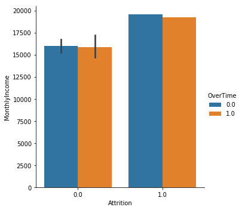

```python
sns.catplot(x='Attrition', y='MonthlyIncome', hue='OverTime', data=df_RD, kind='bar')
```

(7) Work Life Balance - Not Actionable

Of the employees who quit, they had an above average work like balance, which is the opposite of what one would expect. They are happy with with work life balance, but still qutting, even thought they are getting a high salary, so there is something else causing them to quit.

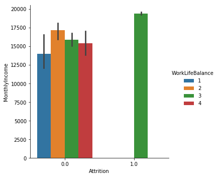

```python
sns.catplot(x='Attrition', y='MonthlyIncome', hue='WorkLifeBalance', data=df_RD, kind='bar')
```

(8) Years with Current Manager - Not Actionable

We were looking for employees who had not been with their manager very long, as thet might indicate that there is an issue with the manager. This data does not show that, and shows that the only employees who quit had been with their manager for 6.8-10.2 years. If the employee didnt like their manager, then wouldnt stay working for them for more than 7 years, so there is something else causing these employees to quit

```python
df_RD['binned_YearsWithCurrManager'] = pd.cut(df_RD.YearsWithCurrManager,5)
```

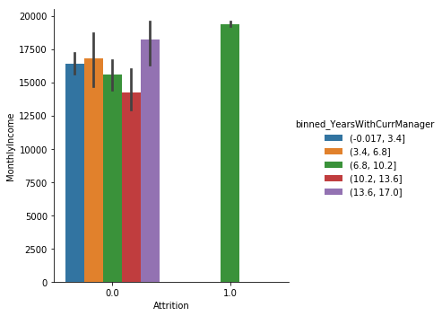

```python
sns.catplot(x='Attrition', y='MonthlyIncome', hue='binned_YearsWithCurrManager', data=df_RD, kind='bar')
```

(9) Environment Satisfaction - Semi-Actionable

Employees who gave a below average environmental satisfaction score (1 or 2) would be more likely to quit. Even though employees who gave a rating of 2 had high monthly income, this could be one reason they quit, in conjunction with another. More data should be gethered to understand this in more detail. For the employees who gave a rating of 4, they like their work environemnt, so something else is causing them to quit.

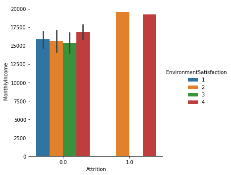

```python
sns.catplot(x='Attrition', y='MonthlyIncome', hue='EnvironmentSatisfaction', data=df_RD, kind='bar')
```

(10) Stock Option Level - Actionable

This is the most powerful datapoint for to answer why Research Directors are quitting. The Research Director role is an upper level executive type of role, which typically means these employees get stock options, to help keep them around and keep them invested in the growth of the company. The only Research directors who quit, were the ones who had zero stock options. Lack of stock options, plus the other minor factors mentioned earlier, are contributing to these employees quitting, with the lack of stock option, we hypothesize, being the greatest contribution.

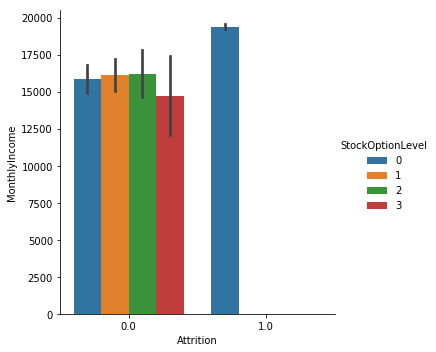

```python
sns.catplot(x='Attrition', y='MonthlyIncome', hue='StockOptionLevel', data=df_RD, kind='bar')
```

**Executive Recommendation: Recommendations to help reduce Attrition from Research Director Employees **  
1) Gather additional information regarding “Job Satisfaction” & “Environment Satisfaction” from Research Director employees  
to understand what could be improved to help raise these scores, to help reduce attrition  
- Use insights gathered to identify actionable steps to reduce attrition  
2) Look into making revisions to the business travel policies  
- Offer higher salary or additional perks for business travelers  
- Look for opportunities to eliminate all business travel if possible  
3) Re-Evaluate overtime requirements and compensation  
- Hire additional employees to help reduce total overtime needed  
- Adjust compensation/perks for Research Directors who work overtime  
4) Provide Stock Options to all Research Director Employees